# Spatial Analysis For Class Arachnida

Nyx Zhang

2023-04-23

Data: https://www.gbif.org/dataset/9c45867f-f77d-42f3-9751-ae16bb7c9bc8 ## Introduction

[figure not shown]

Firstly, we will investigate the spatial characteristics of the Arachnida class. Arachnida is a class of joint-legged invertebrate animals (arthropods), in the subphylum Chelicerata. Arachnida includes, among others, spiders, scorpions, ticks, mites, pseudoscorpions, harvestmen, camel spiders, whip spiders and vinegaroons. https://en.wikipedia.org/wiki/Arachnid

Secondly, within the Arachnida class, there are two primary orders to consider: Araneae and Opiliones. Although many people are familiar with spiders (Araneae), Opiliones, commonly referred to as “harvestmen,” might be less known. There are some physiological differences between them. A primary distinction between spiders and Opiliones is that all spider species produce venom, whereas no known Opiliones species possess venom-producing glands. Although both arachnids have fang-like mouthparts, two pedipalps, and chelicerae, Opiliones lack true fangs, and their jaw muscles are insufficiently strong to penetrate human skin. Consequently, they pose no threat to humans. Furthermore, there is a notable difference in their feeding habits. Spiders typically liquefy their prey, allowing them to consume it through their hollow fangs. In contrast, Opiliones employ a different method, chewing and swallowing their food in a manner more akin to human consumption. https://www.bugs.com/blog/what-is-the-difference-between-spiders-and-opiliones/

We will mainly explore the spacial differences between them.

[figure not shown]

orders

## Data Processing

### Data Loading

We got the data from the Global Biodiversity Information Facility (GBIF) data repository. https://www.gbif.org/dataset/9c45867f-f77d-42f3-9751-ae16bb7c9bc8 The data has the size of 749 rows and 50 columns, where the main information is the variety of the species, as well as the occurred coordinates and dates. However, there are no elevation data to be used.

```r
library(spatstat)
library(dplyr)
# Arachnida <- name_backbone_checklist(Arachnida_$scientificName) # This function can only search by sentificName, so I use the downloaded file to find the taxonKey.

spencer_data_raw <- read.csv("0185303-230224095556074.csv",row.names=NULL,sep='\t')
Arachnida_raw <- spencer_data_raw[spencer_data_raw$class=='Arachnida'& spencer_data_raw$stateProvince=='Bc',]
# Arachnida: 蛛形纲

# Extract useful columns
# spencer_data <- spencer_data_raw[,c('gbifID','datasetKey','occurrenceID','kingdom','phylum','class','order','family','genus','species','taxonRank','scientificName','verbatimScientificName','verbatimScientificNameAuthorship','countryCode','locality','stateProvince','occurrenceStatus','decimalLatitude','decimalLongitude','day','month','year','taxonKey')]


# Remove the rows that have missing coordinates.
Arachnida_org <- Arachnida_raw %>%
  subset(!is.na(decimalLatitude) & !is.na(decimalLongitude))
# sum(Arachnida_org$elevation)
head(Arachnida_org)
```

```
##           gbifID                           datasetKey     occurrenceID  kingdom
## 20712 1632909468 9c45867f-f77d-42f3-9751-ae16bb7c9bc8 SEM-UBC OPI-0065 Animalia
## 20716 1632909464 9c45867f-f77d-42f3-9751-ae16bb7c9bc8 SEM-UBC OPI-0086 Animalia
## 20721 1632909459 9c45867f-f77d-42f3-9751-ae16bb7c9bc8 SEM-UBC OPI-0077 Animalia
## 20726 1632909454 9c45867f-f77d-42f3-9751-ae16bb7c9bc8 SEM-UBC OPI-0078 Animalia
## 20728 1632909452 9c45867f-f77d-42f3-9751-ae16bb7c9bc8 SEM-UBC OPI-0046 Animalia
## 20730 1632909450 9c45867f-f77d-42f3-9751-ae16bb7c9bc8 SEM-UBC OPI-0031 Animalia
##           phylum     class     order          family        genus
## 20712 Arthropoda Arachnida Opiliones    Phalangiidae   Phalangium
## 20716 Arthropoda Arachnida Opiliones  Paranonychidae Paranonychus
## 20721 Arthropoda Arachnida Opiliones Sclerosomatidae   Togwoteeus
## 20726 Arthropoda Arachnida Opiliones Sclerosomatidae   Togwoteeus
## 20728 Arthropoda Arachnida Opiliones    Phalangiidae   Phalangium
## 20730 Arthropoda Arachnida Opiliones    Phalangiidae   Phalangium
##                     species infraspecificEpithet taxonRank
```

[output cut: 90 more lines]

```r
nrow(Arachnida_org)
```

```
## [1] 749
```

```r
ncol(Arachnida_org)
```

```
## [1] 50
```

### Reprojecting

We transformed the coordinates from Lat Long, to BC Albers projection.

```r
library(sp)
coords <- Arachnida_org[, c("decimalLongitude", "decimalLatitude")]
points_wgs84 <- SpatialPoints(coords)

# Set the CRS for the points
crs_wgs84 <- CRS("+proj=longlat +datum=WGS84 +no_defs")
proj4string(points_wgs84) <- crs_wgs84

# Define BC Albers projection string
bc_albers_proj4 <- "+proj=aea +lat_0=45 +lon_0=-126 +lat_1=50 +lat_2=58.5 +x_0=1000000 +y_0=0 +datum=NAD83 +units=m +no_defs"

# Reproject points to BC Albers
points_bc_albers <- spTransform(points_wgs84, CRS(bc_albers_proj4))

reprojected_coords <- as.data.frame(coordinates(points_bc_albers))
Arachnida_crs <- Arachnida_org
Arachnida_crs[,c('decimalLongitude','decimalLatitude')] <- reprojected_coords
head(Arachnida_crs[,c('decimalLongitude','decimalLatitude')] )
```

```
##       decimalLongitude decimalLatitude
## 20712          1410534        779248.3
## 20716          1208576        474735.4
## 20721          1453993        483840.5
## 20726          1473218        474751.7
## 20728          1564868        560696.1
## 20730          1699751        671916.7
```

## First Moment Descriptives

The First Moment Descriptives includes measures that describe the center or location of the spatial data distribution. This includes the mean, median, and mode. The mean represents the average value of Arachnida density across the study area, while the median represents the midpoint of the data distribution, and the mode represents the most frequently occurring value. These measures provide insights into the central tendency of Arachnida density in the study area. The dataset shows that Araneae have 675 occurrences and Opiliones have 74 occurrences. Notably, in 1982, there is a substantial increase in the number of recorded Araneae occurrences, which may suggest potential measurement bias, thus affecting the confidence in the absolute numbers or proportions. Nevertheless, by examining the trendline over the years, it can still be inferred that Araneae are more abundant than Opiliones in the region. Various factors could contribute to this disparity, such as differences in habitat preferences, population sizes, or environmental conditions.

### Count Statistics

Orders in the Araneae family that contribute more than 5% to the total Arachnida class include Lycosidae (26.97%), Gnaphosidae (17.62%), Theridiidae (7.74%), Salticidae (7.21%), and Thomisidae (6.81%). In the case of the Opiliones order, only the Phalangiidae family reaches a proportion above 5%, accounting for 7.61% of the total class.

```r
order_count <- Arachnida_crs %>% group_by(order) %>% summarise(count = n(),.groups = 'drop') %>% mutate(share = round((count / sum(count)), 4)) %>% arrange(desc(count))
family_count <- Arachnida_crs %>% group_by(order,family)  %>% summarise(count = n(),.groups = 'drop') %>% mutate(share = round((count / sum(count)), 4)) %>% arrange(desc(count))
# genus_count <- Arachnida_crs %>%group_by(order,family,genus)  %>% summarise(count = n(),.groups = 'drop') %>% mutate(share = round((count / sum(count)), 4)) %>% arrange(desc(count))
year_count <- Arachnida_crs %>% group_by(order,year)  %>% summarise(count = n(),.groups = 'drop') %>% mutate(share = round((count / sum(count)), 4)) %>% arrange(desc(count))
month_count <- Arachnida_crs %>% group_by(order,month)  %>% summarise(count = n(),.groups = 'drop') %>% mutate(share = round((count / sum(count)), 4)) %>% arrange(month)

order_count
```

```
## # A tibble: 2 × 3
##   order     count  share
##   <chr>     <int>  <dbl>
## 1 Araneae     675 0.901
## 2 Opiliones    74 0.0988
```

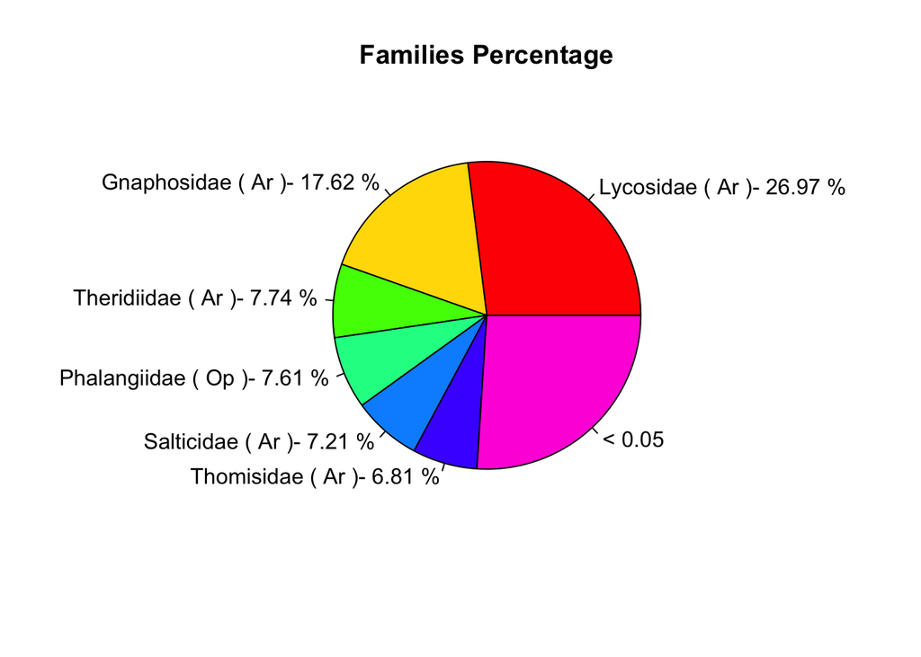

```r
# family
family_count <- data.frame(family=paste(family_count$family,'(',substr(family_count$order,1,2),')-',family_count$share*100,'%'),
                           share=family_count$share)
family_count_filtered <- family_count[family_count$share >= 0.05,c('family','share')]
family_count_new_row <- data.frame(family = "< 0.05",
                                   share = sum(family_count$share[family_count$share < 0.05]))
family_count_new<- rbind(family_count_filtered, family_count_new_row)

pie(family_count_new$share,
    labels =family_count_new$family,
    col = rainbow(length(family_count_new$share)),
    main = "Families Percentage")
```

```r
names(family_count$family)
```

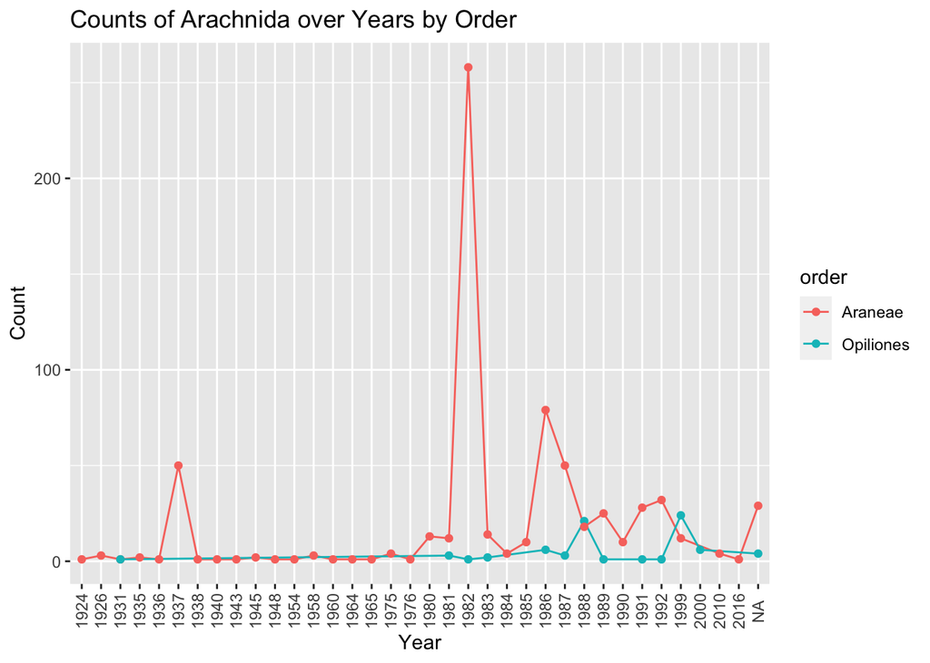

```r
# genus_count
# time
library(ggplot2)


# Create the line plot
plot_year <- ggplot(data.frame(year_count), aes(x = as.character(year), y = count, group = order, color = order,bin=10)) +
  geom_line() +
  geom_point() +
  labs(title = "Counts of Arachnida over Years by Order",
       x = "Year",
       y = "Count") +
    theme(axis.text.x = element_text(angle = 90, vjust = 0.5))
  # theme_minimal()
print(plot_year)
```

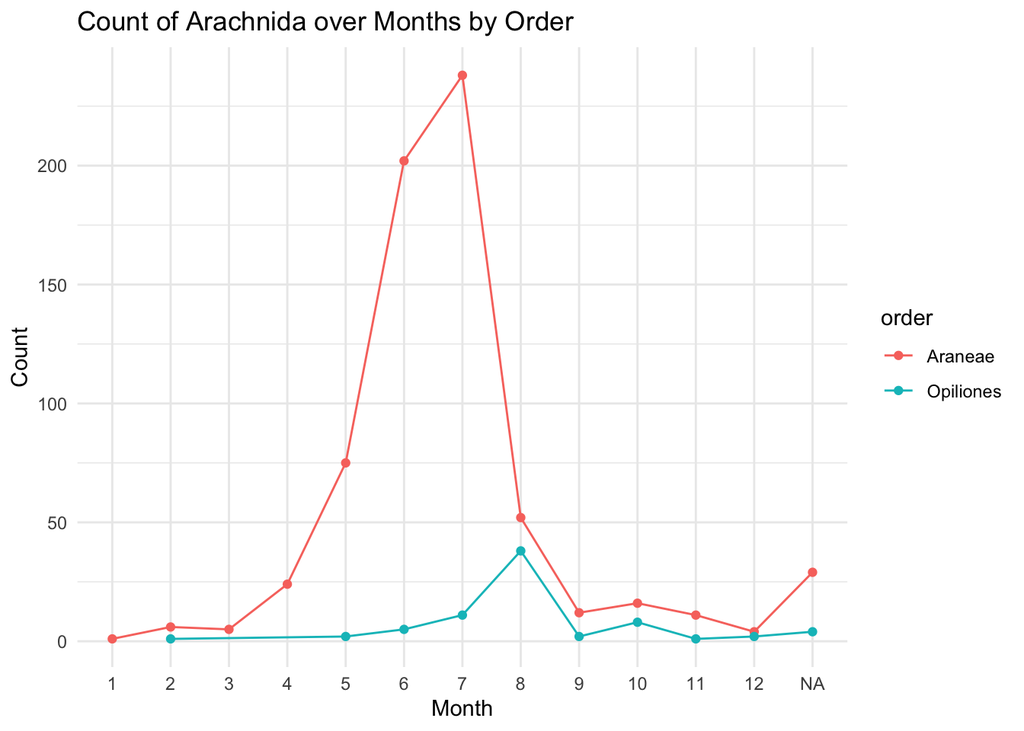

```r
plot_month <- ggplot(data.frame(month_count), aes(x = factor(month), y = count, group = order, color = order)) +
  geom_line() +
  geom_point() +
  labs(title = "Count of Arachnida over Months by Order",
       x = "Month",
       y = "Count") +
  theme_minimal()
print(plot_month)
```

### distribution plot

We drew the distribution plots and marked by the two orders.

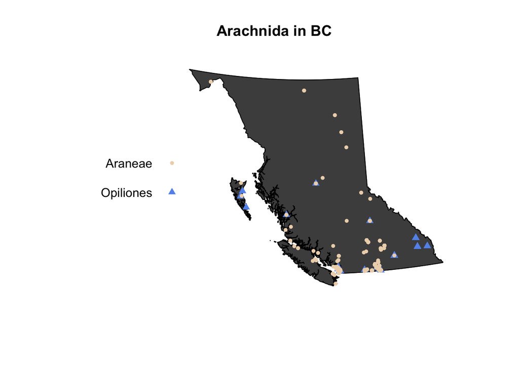

```r
load("BC_Covariates.Rda")
library(maptools)
Arachnida_ppp <- ppp(x = Arachnida_crs$decimalLongitude,
                   y = Arachnida_crs$decimalLatitude,
                   window = as.owin(DATA$Window),
                   marks = Arachnida_crs$order,
                   check = F)


# Preview the point pattern object
plot(Arachnida_ppp,
     col = "grey30",
     main='Arachnida in BC',
     cols = c('bisque2','cornflowerblue'),
     pch = c(16,17),
     cex = c(0.7,1)
     )
```

### Intensity

```r
intensity(Arachnida_ppp)
```

```
## [1] 7.898657e-10
```

```r
intensity(Arachnida_ppp[Arachnida_ppp$marks=='Araneae'])
```

```
## [1] 7.118283e-10
```

```r
intensity(Arachnida_ppp[Arachnida_ppp$marks=='Opiliones'])
```

```
## [1] 7.803747e-11
```

### Quadratcount

According to the 5 by 5 Quadratcount, most of the Arachnida are spotted in the South Middle areas of BC. And most of Araneae are found in the South Middle. whereas Opiliones occur in the South East.

```r
Q_5 <- quadratcount(Arachnida_ppp,
                  nx = 5,
                  ny = 5)

Q_A <- quadratcount(Arachnida_ppp[Arachnida_ppp$marks=='Araneae'],
                  nx = 5,
                  ny = 5)

Q_O <- quadratcount(Arachnida_ppp[Arachnida_ppp$marks=='Opiliones'],
                  nx = 5,
                  ny = 5)
```

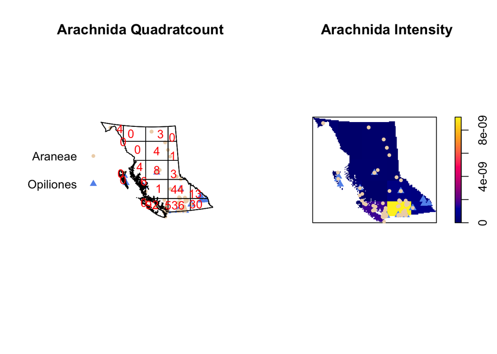

```r
par(mfrow=c(1,2))
plot(Arachnida_ppp,
     pch = c(16,17),
     cex = c(0.7,1),
     cols = c('bisque2','cornflowerblue'),
     main = " Arachnida Quadratcount")
plot(Q_5, cex = 1, col = "red", add = T)

plot(intensity(Q_5, image = T),
     main = "Arachnida Intensity")
plot(Arachnida_ppp,
     cols = c('bisque2','cornflowerblue'),
     pch = c(16,17),
     cex = c(0.7,1),
     add = T)
```

```r
# legend("topleft",c('Araneae','Opiliones'), fill=c('bisque2','cornflowerblue'), cex=0.8)
```

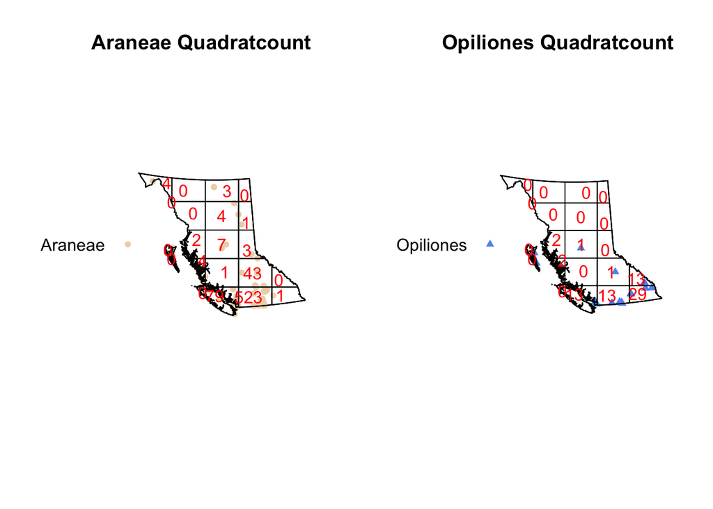

```r
par(mfrow=c(1,2))
plot(Arachnida_ppp[Arachnida_ppp$marks=='Araneae'],
     pch = 16,
     cex = 0.8,
     cols = 'bisque2',
     main = " Araneae Quadratcount")

plot(Q_A, cex = 1, col = "red", add = T)
plot(Arachnida_ppp[Arachnida_ppp$marks=='Opiliones'],
     pch = 17,
     cex = 0.8,
     cols = 'cornflowerblue',
     main = " Opiliones Quadratcount")
plot(Q_O, cex = 1, col = "red", add = T)
```

### Chi-Squared Analysis Then we perform an objective test to assess spatial (in)homogeneity. By conducting a Chi-square test, we evaluate whether the observed deviations are statistically significant. The null hypothesis of this test suggests homogeneity. All the results perform small p-value lower than 2.2e-16, suggesting that we have strong confidence that there is inhomogeneity in locations of Arachnida, Araneae and Opiliones.

```r
quadrat.test(Q_5)
```

```
##
##  Chi-squared test of CSR using quadrat counts
##
## data:
## X2 = 5706.6, df = 20, p-value < 2.2e-16
## alternative hypothesis: two.sided
##
## Quadrats: 21 tiles (irregular windows)
```

```r
quadrat.test(Q_A)
```

```
##
##  Chi-squared test of CSR using quadrat counts
##
## data:
## X2 = 6059.5, df = 20, p-value < 2.2e-16
## alternative hypothesis: two.sided
##
## Quadrats: 21 tiles (irregular windows)
```

```r
quadrat.test(Q_O)
```

```
##
##  Chi-squared test of CSR using quadrat counts
##
## data:
## X2 = 342.94, df = 20, p-value < 2.2e-16
## alternative hypothesis: two.sided
##
## Quadrats: 21 tiles (irregular windows)
```

### Kernel estimation

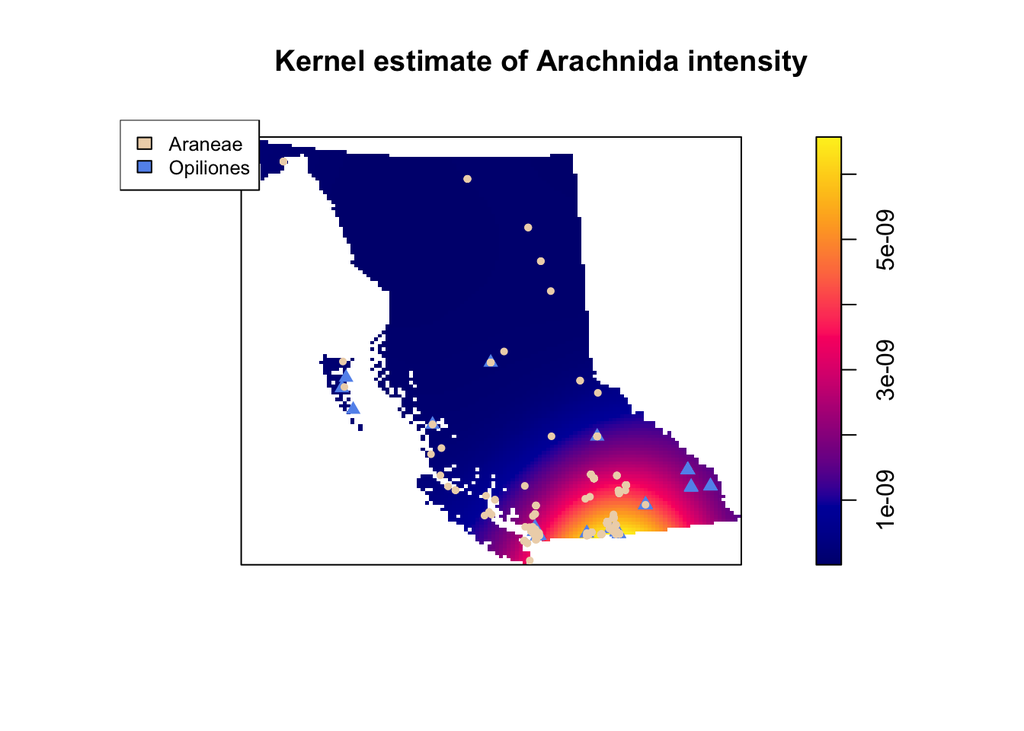

```r
#Density estimation of lambda(u)
lambda_u_hat <- density(Arachnida_ppp)

#Plot the output Note the use of image = TRUE
plot(lambda_u_hat,
     main = "Kernel estimate of Arachnida intensity")

plot(Arachnida_ppp,
     cols = c('bisque2','cornflowerblue'),
     pch = c(16,17),
     cex = c(0.7,1),
     add = T)

legend("topleft",c('Araneae','Opiliones'), fill=c('bisque2','cornflowerblue'), cex=0.8)
```

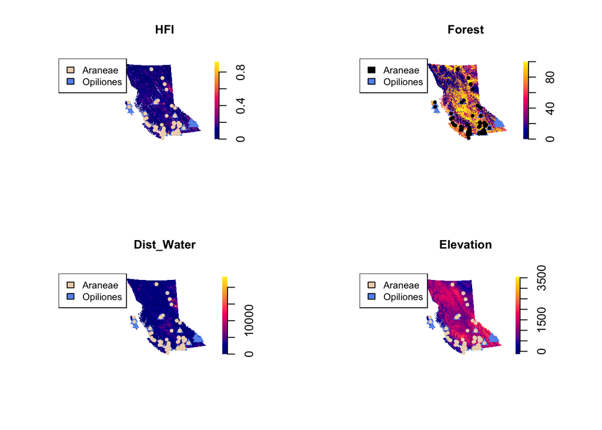

```r
par(mfrow=c(2,2))
plot(DATA$HFI, box = F, par(cex.main = 1), main = "HFI")
plot(Arachnida_ppp,
     cols = c('bisque2','cornflowerblue'),
     pch = c(16,17),
     cex = c(0.7,1),
     add = T)
legend("topleft",c('Araneae','Opiliones'), fill=c('bisque2','cornflowerblue'), cex=0.8)

plot(DATA$Forest, box = F, par(cex.main = 1), main = "Forest")
plot(Arachnida_ppp,
     cols = c('black','cornflowerblue'),
     pch = c(16,17),
     cex = c(0.7,1),
     add = T)
legend("topleft",c('Araneae','Opiliones'), fill=c('black','cornflowerblue'), cex=0.8)

plot(DATA$Dist_Water, box = F, par(cex.main = 1), main = "Dist_Water")
plot(Arachnida_ppp,
     cols = c('bisque2','cornflowerblue'),
     pch = c(16,17),
     cex = c(0.7,1),
     add = T)
legend("topleft",c('Araneae','Opiliones'), fill=c('bisque2','cornflowerblue'), cex=0.8)

plot(DATA$Elevation, box = F, par(cex.main = 1), main = "Elevation")
plot(Arachnida_ppp,
     cols = c('bisque2','cornflowerblue'),
     pch = c(16,17),
     cex = c(0.7,1),
     add = T)
legend("topleft",c('Araneae','Opiliones'), fill=c('bisque2','cornflowerblue'), cex=0.8)
```

## Second Moment Descriptive The Second Moment Descriptives includes measures that describe the variability or spread of the Arachnida density distribution in the study area. This includes measures such as variance, standard deviation, and range. The variance represents the average distance between each value and the mean, while the standard deviation represents the square root of the variance. The range is the difference between the maximum and minimum values of Arachnida density in the study area. These measures provide insights into the degree of variability in Arachnida density across the study area.

### Morisita’s Index plot

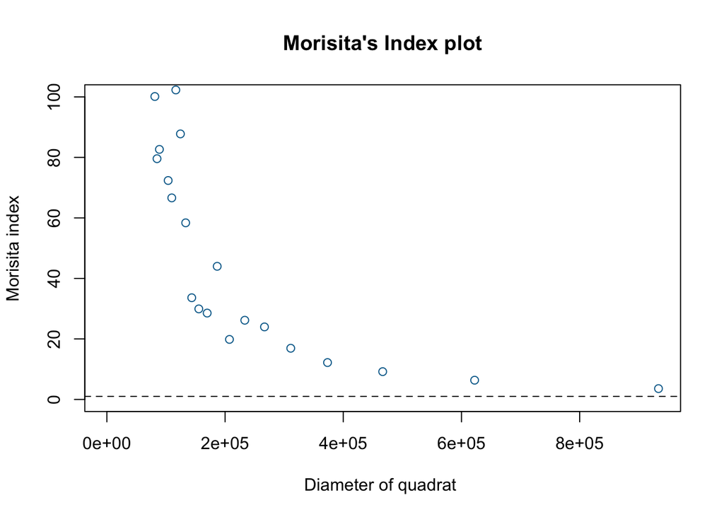

```r
Arachnida_ppp_sq <- ppp(x = Arachnida_crs$decimalLongitude,
                   y = Arachnida_crs$decimalLatitude,
                   window = owin(c(min(Arachnida_crs$decimalLongitude),max( Arachnida_crs$decimalLongitude)),
                                 c(min(Arachnida_crs$decimalLatitude),max(Arachnida_crs$decimalLatitude))),
                   marks = Arachnida_crs$order,
                   check = F)
miplot(Arachnida_ppp_sq,main="Morisita's Index plot",col = "#046C9A",ylim=c(0,100))
```

### Ripley’s K function

For the spacing (or distance) between points, we calculated the Ripley’s K function, which is a function of the area of a circle with radius r. Any deviations between the empirical and theoretical K-functions can show an indication of correlations between points. From the plot, significant clustering only appears to exist in and around 0-15000 meters.

```r
#Estimate a strictly positive density
lambda_Arachnida_pos <- density(Arachnida_ppp_sq,
                          sigma=bw.ppl,
                          positive=TRUE)

#Simulation envelope (with points drawn from the estimated intensity)
E_Arachnida_inhom <- envelope(Arachnida_ppp_sq,
                        Kinhom,
                        simulate = expression(rpoispp(lambda_Arachnida_pos)),
                        correction="border",
                        rank = 1,
                        nsim = 19,
                        fix.n = TRUE)
```

```
## Generating 19 simulations by evaluating expression  ...
## 1, 2, 3, 4, 5, 6, 7, 8, 9, 10, 11, 12, 13, 14, 15, 16, 17, 18,  19.
##
## Done.
```

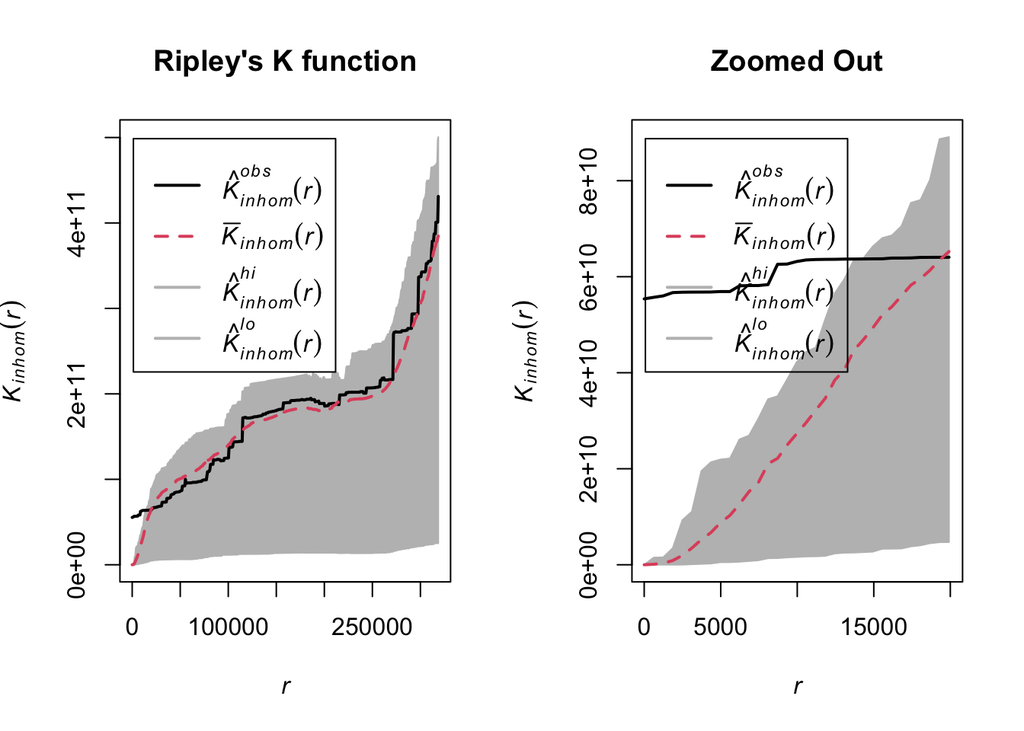

```r
par(mfrow = c(1,2))
plot(E_Arachnida_inhom,
     main = "Ripley's K function",
     lwd = 2)
plot(E_Arachnida_inhom,
     main = "Zoomed Out",
     lwd = 2,
     xlim=c(0,20000))
```

```r
# Estimate the g function
pcf_Arachnida <- pcf(Arachnida_ppp_sq)

pcf_Arachnida_inhom <- envelope(Arachnida_ppp_sq,
                          pcfinhom,
                          simulate = expression(rpoispp(lambda_Arachnida_pos)),
                          rank = 1,
                          nsim = 19)
```

```
## Generating 19 simulations by evaluating expression  ...
## 1, 2, 3, 4, 5, 6, 7, 8, 9, 10, 11, 12, 13, 14, 15, 16, 17, 18,  19.
##
## Done.
```

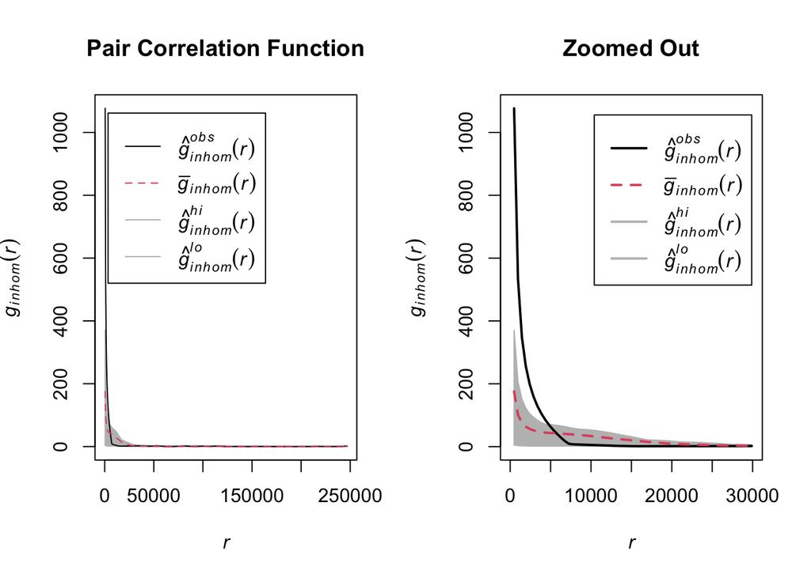

```r
par(mfrow = c(1,2))

plot(pcf_Arachnida_inhom,main='Pair Correlation Function')
# Zoom in on range where significant deviations appear

plot(pcf_Arachnida_inhom,
     xlim = c(0,3e+4),
     main='Zoomed Out',
     lwd = 2)
```